# Using Sentiment Analysis to Measure the Influence of Stock-related Tweets in Forecasting Technology Sector Stock Prices

Yazan Zeeshan Ali, Phuong Hanh Bui, Jacob Brandt, Vinuthna Kondipati, and Ritika Nandi

April 18, 2023

## Introduction

The stock market is one of the most widely studied subjects with numerous participants in research from top financial firms to academia aiming to understand not only how to make accurate predictions but to understand its behavior. Its movements are influenced by various internal and external factors such as political and legal events, economic cycles, and even social media trends. With the rise of social media platforms providing greater transparency, velocity, and exchange of information, it is now easier than ever for financial market participants to follow and analyze the market and individual stock. In this project, sentiment analysis is applied using a statistical machine learning model to capture the correlation between the tweets extracted from Twitter and stock’s price market movements. This project seeks to answer the following research question:

How would daily stock prices behave in response to a positive, neutral, or negative sentiment scoring of tweets related to the respective stock?

## Data Cleaning

Import all the necessary libraries and set the seed to a constant value (1031).

```r
library(stringr)
library(tm)
library(SnowballC)
library(NLP)
library(textrank)
library(tidytext)
library(h2o)
library(dplyr)
library(readr)
library(stringr)
library(tm)
library(lexRankr)
library(vader)
library(ISLR2)
library(caret)
library(ISLR)
library(caTools)
library(ggplot2)
library(mgcv)
library(dplyr)
library(ROCR)
library(car)
library(leaps)
library(glmnet)
library(stringi)
library(reshape2)
library(skimr)
library(rpart)
library(rpart.plot)
library(extremeStat)
library(ranger)
library(tidyverse)
library(ggplot2)
library(gridExtra)
library(lubridate)
library(tidyr)
library(e1071)
library(tm)

set.seed(1031)
h2o.init()
```

```
##  Connection successful!
##
## R is connected to the H2O cluster:
##     H2O cluster uptime:         22 minutes 24 seconds
##     H2O cluster timezone:       America/New_York
##     H2O data parsing timezone:  UTC
##     H2O cluster version:        3.40.0.1
##     H2O cluster version age:    2 months and 10 days
##     H2O cluster name:           H2O_started_from_R_Ritika_nmx808
##     H2O cluster total nodes:    1
##     H2O cluster total memory:   1.88 GB
##     H2O cluster total cores:    8
##     H2O cluster allowed cores:  8
##     H2O cluster healthy:        TRUE
##     H2O Connection ip:          localhost
##     H2O Connection port:        54321
##     H2O Connection proxy:       NA
##     H2O Internal Security:      FALSE
##     R Version:                  R version 4.2.2 (2022-10-31 ucrt)
```

Function to clean the entire each tweet by splitting compound words, removing non-ASCII characters, hyperlinks.

```r
clean_tweet <- function(tweet_list, is_bytes = FALSE) {
  # Load required libraries
  library(stringr)
  library(tm)

  # Define function to split compound words
  compound_word_split <- function(compound_word) {
    matches <- gregexpr('.+?(?:(?<=[a-z])(?=[A-Z])|(?<=[A-Z])(?=[A-Z][a-z])|$)', compound_word, perl = TRUE)
    regmatches(compound_word, matches)[[1]]
  }

  # Define function to remove non-ASCII characters
  remove_non_ascii_chars <- function(text) {
    iconv(text, from = "UTF-8", to = "ASCII//TRANSLIT")
  }

  # Define function to remove hyperlinks
  remove_hyperlinks <- function(text) {
    gsub("\\bhttps?://\\S+\\b", "", text, perl = TRUE)
  }

  # Define stop words and punctuation table
  stop_words <- stopwords("english")
  punc_table <- chartr(punctuation, " ", "")

  # Define function to clean a single tweet
  get_cleaned_text <- function(text) {
    cleaned_tweet <- gsub('\"|\'', '', text) %>%
      remove_non_ascii_chars() %>%
      remove_hyperlinks() %>%
      gsub('#', 'HASHTAGSYMBOL', .) %>%
      gsub('@', 'ATSYMBOL', .) %>%
      str_split(pattern = "\\s+") %>%
      unlist() %>%
      tolower() %>%
      .[! . %in% stop_words & nchar(.) > 1] %>%
      sapply(compound_word_split) %>%
      paste(collapse = " ") %>%
      gsub('HASHTAGSYMBOL', '#', .) %>%
      gsub('ATSYMBOL', '@', .)
    return(cleaned_tweet)
  }

  # Define function to clean a list of tweets
  if (is_bytes) {
    tweet_list <- sapply(tweet_list, function(x) get_cleaned_text(iconv(x, "UTF-8")))
  } else {
    tweet_list <- sapply(tweet_list, get_cleaned_text)
  }

  return(tweet_list)
}
```

Function to clean the entire dataset for each company

```r
clean_file <- function(company_name) {
  f = read.csv('original tweets_stocks.csv')
  punctuation <- c(",", ".", "!", "?", ";", ":", "-", "_", "/", "\\", "|", "(", ")", "[", "]", "{", "}", "<", ">", "\"", "'", "`", "~", "@", "#", "$", "%", "^", "&", "*", "+", "=")
  tw = clean_tweet(f, is_bytes = FALSE)
  f$Tweets = tw
  f1 = subset(f, select = -c(ticker_symbol,tweet_id,close_value,volume,open_value,high_value,low_value,body))
  write.csv(f1, file = paste0('tweets_', company_name, '.csv'), row.names = F)
}
```

Function is used to group all tweets together by day and make a new csv file

```r
processTweets <- function(company_name) {

  columns <- c('Date', 'Tweets')
  data <- data.frame(matrix(nrow = 0, ncol = length(columns)))
  colnames(data) <- columns

  df <- read.csv(paste0('tweets_', company_name, '.csv'), header = F, col.names = columns, encoding = 'UTF-8')

  indx <- 0
  get_tweet <- ""

  # get tweets day wise
  for (i in 1:(nrow(df)-1)) {
    get_date <- df$Date[i]
    next_date <- df$Date[i+1]
    if (!is.na(get_date) && !is.na(next_date) && get_date == next_date) {

      get_tweet <- paste(get_tweet, df$Tweets[i], sep = " . ")
    }
    if (!is.na(get_date) && !is.na(next_date) && get_date != next_date) {

      data[indx, 'Date'] <- get_date
      data[indx, 'Tweets'] <- get_tweet
      indx <- indx + 1
      get_tweet <- " "
    }
  }

  # save cleaned data to a CSV file
  write.csv(data, file = paste0('processedTweets_', company_name, '.csv'), row.names = F)
}
```

This algorithm is more accurate than the method is currently used for text summarization however, because of the slow runtime due to cpu/gpu limitation, it cannot be used in a practical sense.

```r
lexrank_top4 <- function(text) {
  # Run LexRank algorithm
  top_4 <- lexRank(text,
                   # Only 1 article; repeat same docid for all of input vector
                   docId = rep(1, length(text)),
                   # Return 4 sentences to mimic /u/autotldr's output
                   n = 4,
                   continuous = TRUE)

  # Reorder the top 4 sentences to be in order of appearance in article
  order_of_appearance <- order(as.integer(gsub("_", "", top_4$sentenceId)))
  # Extract sentences in order of appearance
  ordered_top_4 <- top_4[order_of_appearance, "sentence"]

  # Return the top 3 sentences as a single string
  s <- paste(ordered_top_4, collapse = " ")
  return(s)
}
```

We read the processed file we generated in the previous step and create and a subset of tweets after 1st april 2017

```r
tweets_subset <- function(company_name) {
  path = paste0("./processedTweets_", company_name, ".csv")
  d = read.csv(path)
  len = nrow(d)
  d_subset = d[(len-1003) : len,]
  return(d_subset)
}
```

This function summarizes the tweets for each day by selecting the first 5 relevant tweets returned by the tibble function. This is not the most efficient approach however its the only one which works in a reasonable time frame.

```r
summarize_article <- function(article_text) {
  article_sentences <- tibble(text = article_text) %>%
    unnest_tokens(sentence, text, token = "sentences") %>%
    mutate(sentence_id = row_number()) %>%
    select(sentence_id, sentence)
    return(paste0(article_sentences$sentence[1:5], collapse = " "))
}
```

We apply the summarize article function to all the tweets here and drop the old tweets column to reduce the load on storage

```r
data_summ = function(df) {
  df$summ_text = ""
  for (i in 1 :nrow(df)){
    df$summ_text[i] = summarize_article(df$Tweets[i])
  }

  df1 = subset(df, select = -c(Tweets) )

  return(df1)
}
```

## Sentiment Analysis

We use vader library for the sentiment analysis on the summarized tweets.

```r
sentimentAnalysis <- function(df, company_name) {
  data = df
  data$Comp <- ""
  data$Negative <- ""
  data$Neutral <- ""
  data$Positive <- ""
  for (i in 1:nrow(data)) {
      sentence_sentiment <- get_vader(data$summ_text[i])
      data$Comp[i] <- sentence_sentiment['compound']
      data$Negative[i] <- sentence_sentiment['neg']
      data$Neutral[i] <- sentence_sentiment['neu']
      data$Positive[i] <- sentence_sentiment['pos']
  }
  data <- data[, !grepl("Unnamed", names(data))] # remove unnamed column
  data = subset(data, select = -c(summ_text))
  write.csv(data, file = paste0("sentimentAnalysis_", company_name, ".csv"), row.names = FALSE)
}
```

We create a function to visualize the distribution of sentiments across all companies

```r
sentimentDistribution <- function(company_name) {
  path_sentiment = paste0("./sentimentAnalysis_", company_name, ".csv")
  df = read.csv(path_sentiment)
  df$Date <- as.Date(df$Date)
  df$Month <- months(df$Date)
  df$Year <- format(df$Date,format="%y")
  df$week <- floor_date(df$Date, "week")


  print(ggplot(data=df, aes(x=Date, y=Positive)) +
          geom_line()+
          labs(title="df Positive Sentiment",x="Date", y = "Proportion of Positive Sentments")+
          geom_smooth())

  print(ggplot(data=df, aes(x=Date, y=Neutral)) +
          geom_line()+
          labs(title="df Neutral Sentiment",x="Date", y = "Proportion of Neutral Sentments")+
          geom_smooth())

  print(ggplot(data=df, aes(x=Date, y=Negative)) +
          geom_line()+
          labs(title="df Negative Sentiment",x="Date", y = "Proportion of Negative Sentments")+
          geom_smooth())

  print(ggplot(data = df, aes(x = Date)) +
          geom_line(aes(y = Positive, color = "Positive")) +
          geom_smooth(aes(y = Positive, color = "Positive"), color = "black") +
          geom_line(aes(y = Neutral, color = "Neutral")) +
          geom_smooth(aes(y = Neutral, color = "Neutral"), color = "black") +
          geom_line(aes(y = Negative, color = "Negative")) +
          geom_smooth(aes(y = Negative, color = "Negative"), color = "black") +
          labs(title = "df Sentiment", x = "Date", y = "Proportion of Sentiments", color = "Sentiment") +
          scale_color_manual(values = c("Positive" = "blue", "Neutral" = "orange", "Negative" = "red")))


  slices <- c(mean(df$Positive), mean(df$Neutral),mean(df$Negative))
  lbls <- c("Positive", "Neutral", "Negative")
  pct <- round(slices/sum(slices)*100)
  lbls <- paste(lbls, pct) # add percents to labels
  lbls <- paste(lbls,"%",sep="") # ad % to labels
  title = paste0("Average Proportion of Twitter Sentiment on ", company_name)
  print(pie(slices,labels = lbls, col=c("#2b8cbe", "#edf8b1","#de2d26"),
            main=title,
            sub = "April 2017 - January 2020"))
}
```

Next we add adjusted close price of each stock to the the generated sentiment analysis files and drop NA rows because there are no stock prices for weekends and holidays.

```r
add_close_price <- function(company_name) {
  path_stock = paste0("./stockData_", company_name, ".csv")
  stocks_df = read.csv(path_stock)

  path_sentiment = paste0("./sentimentAnalysis_", company_name, ".csv")
  company_df = read.csv(path_sentiment)

  merged_df = merge(company_df, subset(stocks_df)[c("Date", "Adj.Close")],
                    by = "Date", all.x = TRUE)
  merged_df = merged_df[!is.na(merged_df$Adj.Close), ]
  final_path = paste0("./sentimentAnalysisWithPrice_", company_name, ".csv")
  write.csv(merged_df, final_path, row.names = FALSE)
}
```

## Random Forest

Building a Random Forest model and running it on the final file

```r
randomForest <- function(company_name) {
  path = paste0("./sentimentAnalysisWithPrice_", company_name, ".csv")
  data = read.csv(path)
  new_data <- data %>% select(-c(Comp))
  split = createDataPartition(y=new_data$Adj.Close,
                                   p = 0.7,
                                   list = F,
                                   groups = 100)
  train = new_data[split,]
  test = new_data[-split,]

  ##RANDOM FOREST MODEL WITHOUT TUNING
  forest_ranger = ranger(Adj.Close~.-Date,
                              data = train,
                              num.trees = 1000)
  pred_train_forest_ranger = predict(forest_ranger, data = train, num.trees = 1000)
  rmse_train_forest_ranger = sqrt(mean((pred_train_forest_ranger$predictions - train$Adj.Close)^2))

  #predict on test set
  pred_test_forest_ranger = predict(forest_ranger, data = test, num.trees = 1000)
  rmse_test_forest_ranger = sqrt(mean((pred_test_forest_ranger$predictions - test$Adj.Close)^2))

  pred_test_pred_1 = pred_test_forest_ranger$predictions
  ##RANGER WITH TUNING PARAMETERS
  trControl=trainControl(method="cv",number=5)
  tuneGrid = expand.grid(mtry=1:ncol(train)-2,
                              splitrule = c('variance','extratrees','maxstat'),
                              min.node.size = c(2,5,10,15,20,25))
  set.seed(1031)
  cvModel = train(Adj.Close~.-Date,
                       data=train,
                       method="ranger",
                       num.trees=1000,
                       trControl=trControl,
                       tuneGrid=tuneGrid)
  cvModel$bestTune

  set.seed(1031)
  cv_forest_ranger = ranger(Adj.Close~.-Date,
                                 data=train,
                                 num.trees = 1000,
                                 mtry=cvModel$bestTune$mtry,
                                 min.node.size = cvModel$bestTune$min.node.size,
                                 splitrule = cvModel$bestTune$splitrule)

  pred_train = predict(cv_forest_ranger, data = train, num.trees = 1000)
  rmse_train_cv_forest_ranger = sqrt(mean((pred_train$predictions - train$Adj.Close)^2))

  #predict tuned RF on test set
  pred_test = predict (cv_forest_ranger, data = test, num.trees = 1000)
  rmse_test_cv_forest_ranger = sqrt(mean((pred_test$predictions - test$Adj.Close)^2))
  pred_test_pred = pred_test$predictions

  ################################################################################

  ## PLOT FOR TUNED RANGER
  plot_df <- select(data, Date, Adj.Close)
  test_plot <- plot_df[-split,]
  df <- cbind(test_plot, pred_test_pred)

  # Convert Date column to Date format
  df$Date <- as.Date(df$Date)

  # Group data by year and month, and select the first day of each month
  df_monthly <- df %>%
    group_by(year(Date), month(Date)) %>%
    slice(1)

  # Create the plot
  title = paste0("Random Forest Prediction for ", company_name)
  print(ggplot(data = df, aes(x = Date)) +
    geom_point(aes(y = Adj.Close, color = "Actual")) +
    geom_point(aes(y = pred_test_pred, color = "Predicted")) +
    scale_color_manual(values = c("Actual" = "blue", "Predicted" = "red")) +
    labs(x = "Date", y = "Adj.Close", title = title) +
    theme_bw() +
    theme(axis.text.x = element_text(angle = 90, hjust = 1)) +
    scale_x_date(date_breaks = "1 month", date_labels = "%Y-%m-%d", minor_breaks = NULL))

  ## PLOT FOR UN-TUNED RANGER
  plot_df_untuned <- select(data, Date, Adj.Close)
  test_plot_untuned <- plot_df_untuned[-split,]
  df_untuned <- cbind(test_plot_untuned, pred_test_pred_1)

  # Convert Date column to Date format
  df_untuned$Date <- as.Date(df_untuned$Date)

  # Group data by year and month, and select the first day of each month
  df_monthly_untuned <- df_untuned %>%
    group_by(year(Date), month(Date)) %>%
    slice(1)

  # Create the plot
  print(ggplot(data = df_untuned, aes(x = Date)) +
    geom_point(aes(y = Adj.Close, color = "Actual")) +
    geom_point(aes(y = pred_test_pred_1, color = "Predicted")) +
    scale_color_manual(values = c("Actual" = "blue", "Predicted" = "red")) +
    labs(x = "Date", y = "Adj.Close", title = title) +
    theme_bw() +
    theme(axis.text.x = element_text(angle = 90, hjust = 1)) +
    scale_x_date(date_breaks = "1 month", date_labels = "%Y-%m-%d", minor_breaks = NULL))

  return (list(rmse_test_cv_forest_ranger = rmse_test_cv_forest_ranger, rmse_test_forest_ranger = rmse_test_forest_ranger))

}
```

## Support Vector Machine

Building a Support Vector Machine model and running it on the final file

```r
supportVectorMachine <- function(company_name) {
  path = paste0("./sentimentAnalysisWithPrice_", company_name, ".csv")
  df = read.csv(path)
  train <- df[1:floor(0.8*nrow(df)),]
  test <- df[(floor(0.8*nrow(df))+1):nrow(df),]


  sentiment_score_list_train <- list()
  for (date in 1:nrow(train)) {
    sentiment_score <- c(train[date, "Negative"], train[date, "Neutral"], train[date, "Positive"])
    sentiment_score_list_train[[date]] <- sentiment_score
  }

  numpy_df_train <- do.call(rbind, sentiment_score_list_train)
  y_train <- as.matrix(train$Adj.Close)

  sentiment_score_list_test <- list()
  for (date in 1:nrow(test)) {
    sentiment_score <- c(test[date, "Negative"], test[date, "Neutral"], test[date, "Positive"])
    sentiment_score_list_test[[date]] <- sentiment_score
  }

  numpy_df_test <- do.call(rbind, sentiment_score_list_test)
  y_test <- as.matrix(test$Adj.Close)

  svr_rbf <- svm(x = numpy_df_train, y = y_train, kernel = 'linear', cost = 1e6, maxiter = 1000)
  output_test_svm <- predict(svr_rbf, numpy_df_test)

  rmse <- sqrt(mean((y_test - output_test_svm)^2))

  # Combine actual and predicted values into a data frame
  actual_vs_predicted <- data.frame(Date = as.Date(test$Date), Actual = y_test, Predicted = output_test_svm)

  # Plot actual and predicted values
  title = paste0("Support Vector Machine for ", company_name)
  print(ggplot(data = actual_vs_predicted, aes(x = Date)) +
    geom_line(aes(y = Actual, color = "Actual")) +
    geom_line(aes(y = Predicted, color = "Predicted")) +
    scale_color_manual(values = c("Actual" = "blue", "Predicted" = "red")) +
    labs(title = title, y = "Price") +
    theme_bw())
  return(rmse)
}
```

## Neural Network

Building a Neural Network model and running it on the final file.

```r
neuralnetwork <- function(company_name, epochs) {
  path = paste0("./sentimentAnalysisWithPrice_", company_name, ".csv")
  df = read.csv(path)

  df = select(df, c("Adj.Close", "Negative", "Neutral", "Positive"))
  df = df[!is.na(df$Adj.Close), ]


  h2o_data = as.h2o(df)

  split <- h2o.splitFrame(h2o_data, ratios = 0.8, seed = 1031)
  train_data <- split[[1]]
  test_data <- split[[2]]

  x <- names(df[, -1])
  y <- names(df)[1]

  hyper_parameters = list(activation=c('Rectifier','Tanh','Maxout','RectifierWithDropout','TanhWithDropout','MaxoutWithDropout'),
                          hidden=list(c(20,20),c(50,50),c(100,100,100), c(30,30,30),c(50,50,50,50),c(25,25,25,25)),
                          l1=seq(0,1e-4,1e-6),
                          l2=seq(0,1e-4,1e-6))

  search_criteria = list(strategy='RandomDiscrete',
                         max_runtime_secs=360,
                         max_models=100,
                         seed=1031,
                         stopping_rounds=5,
                         stopping_tolerance=1e-2)


  grid = h2o.grid(algorithm='deeplearning',
                  grid_id='dl_grid_random',
                  training_frame = train_data,
                  validation_frame=test_data,
                  x=x,
                  y=y,
                  epochs=epochs,
                  hyper_params = hyper_parameters,
                  search_criteria = search_criteria)

  grid = h2o.getGrid(grid_id = "dl_grid_random",sort_by="rmse",decreasing=FALSE)

  best_model = h2o.getModel(grid@model_ids[[1]])
  best_params = best_model@allparameters
  rmse = grid@summary_table$rmse[1]
  h2o.rm("dl_grid_random", cascade = TRUE)
  h2o.rm(best_model, cascade = TRUE)
  return(rmse)
}
```

Compiling the complete model

```r
main <- function(company_name) {
  clean_file(company_name)
  processTweets(company_name)
  df = tweets_subset(company_name)
  summ_data = data_summ(df)
  sentimentAnalysis(summ_data, company_name)
  sentimentDistribution(company_name)
  add_close_price(company_name)
  rmse_rf = randomForest(company_name)
  rmse_svm = supportVectorMachine(company_name)
  rmse_nn = neuralnetwork(company_name, 10)
  return((list(rmse_test_forest_ranger = rmse_rf$rmse_test_forest_ranger, rmse_test_cv_forest_ranger = rmse_rf$rmse_test_cv_forest_ranger, rmse_svm = rmse_svm, rmse_neural_network = rmse_nn)))
}
```

## Analysis

We call the main function on each company to make predictions and check how well our model is performing

### Apple

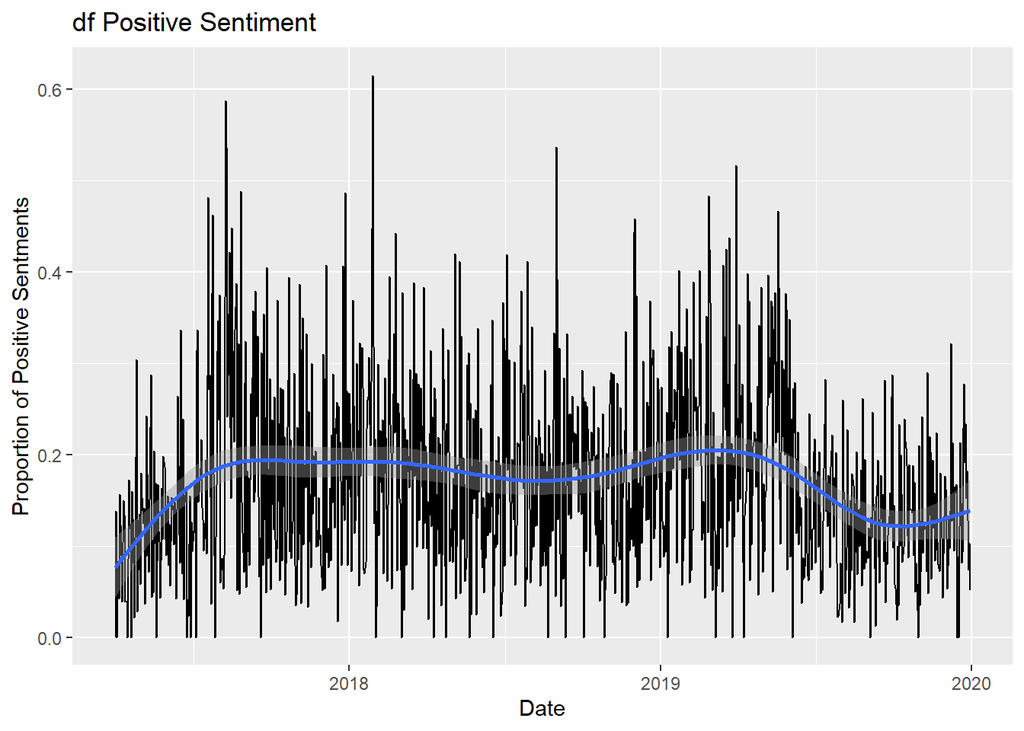

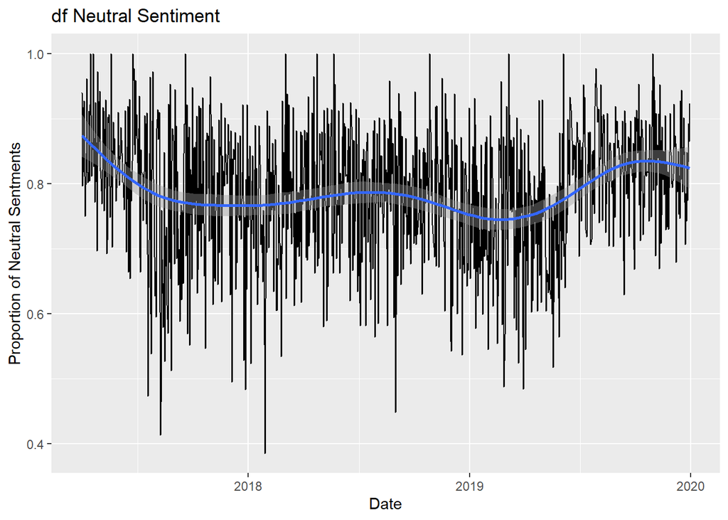

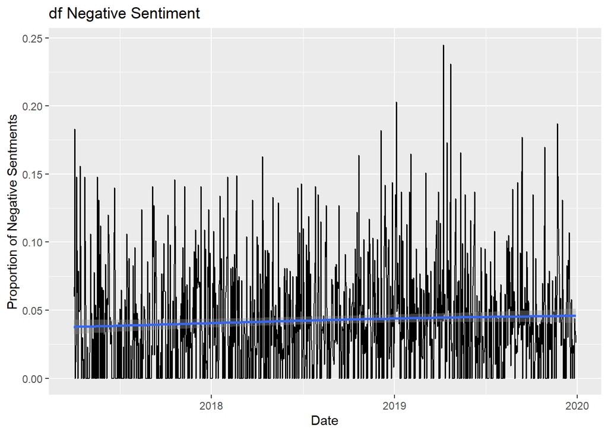

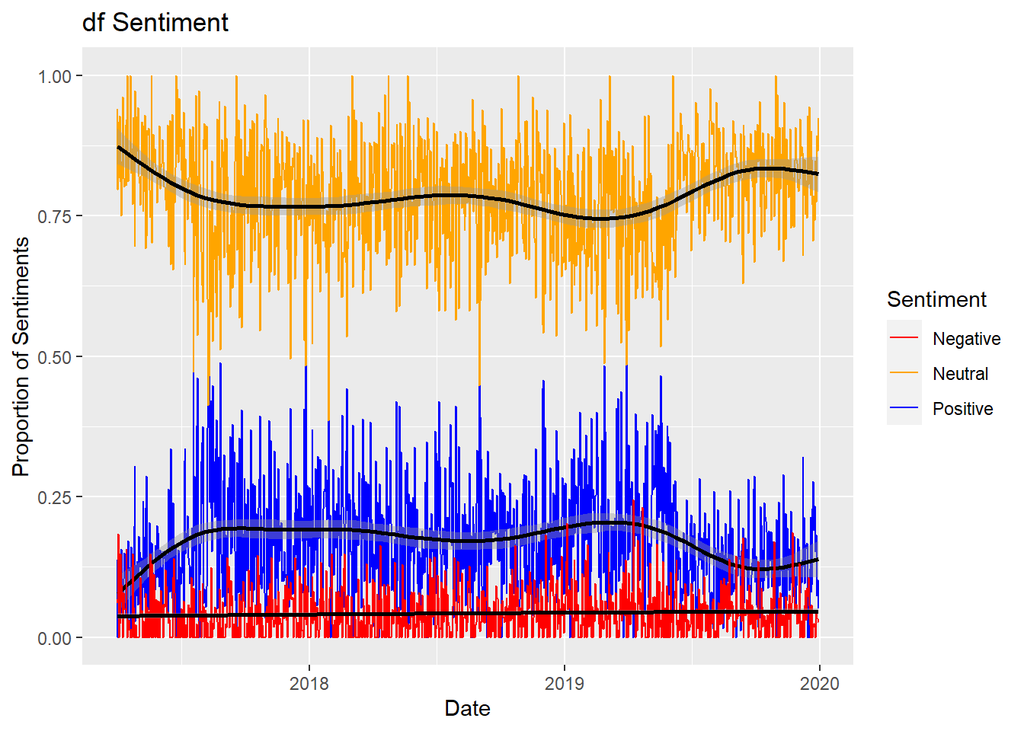

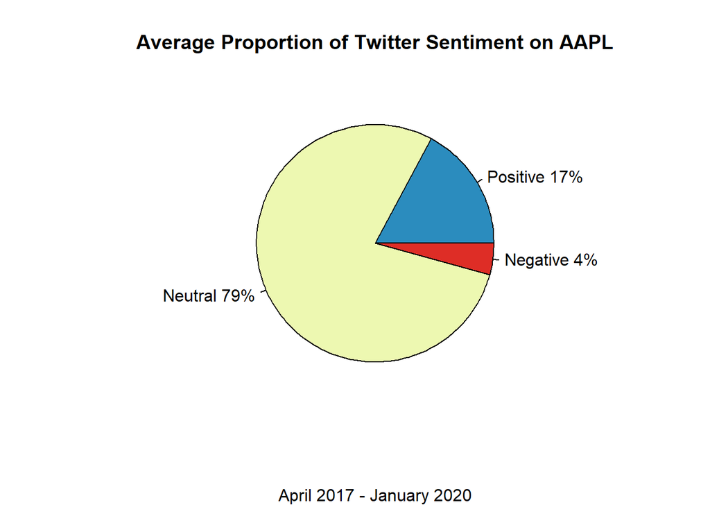

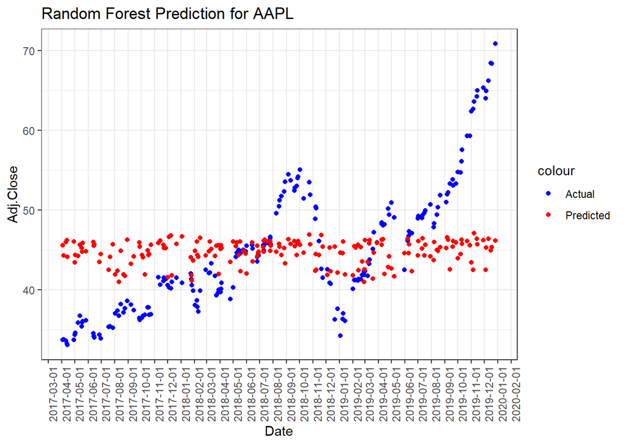

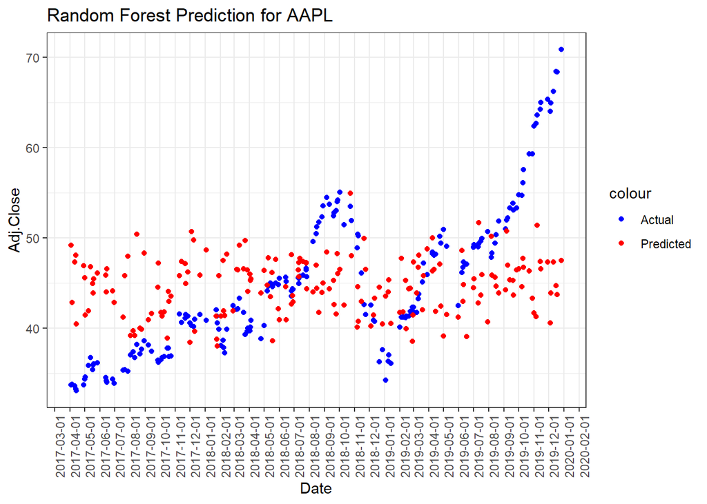

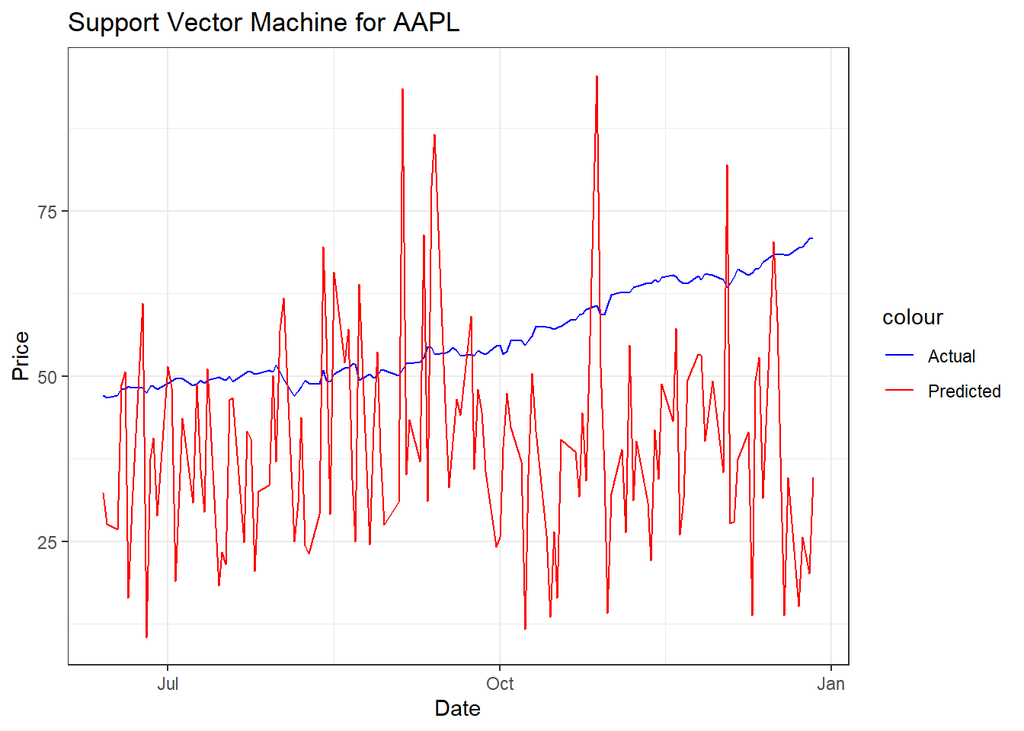

```
## $rmse_test_forest_ranger
## [1] 8.235868
##
## $rmse_test_cv_forest_ranger
## [1] 8.008255
##
## $rmse_svm
## [1] 23.99232
##
## $rmse_neural_network
## [1] 8.111595
```

```r
main('AAPL')
```

### Google

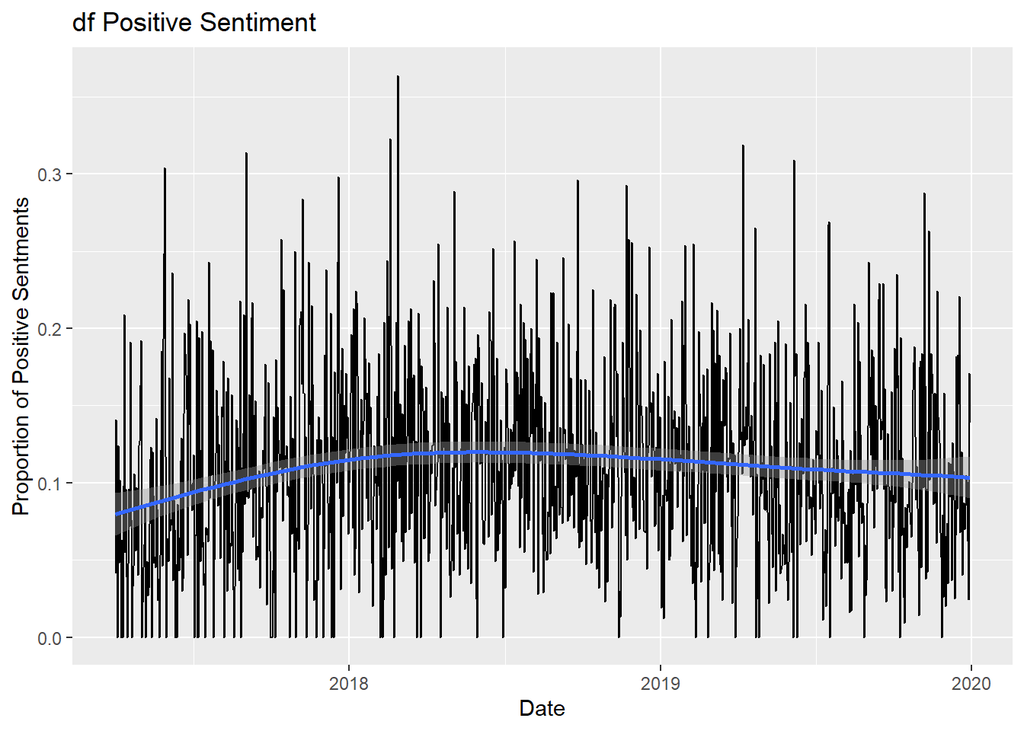

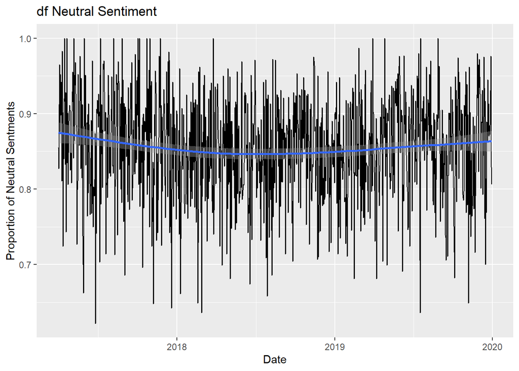

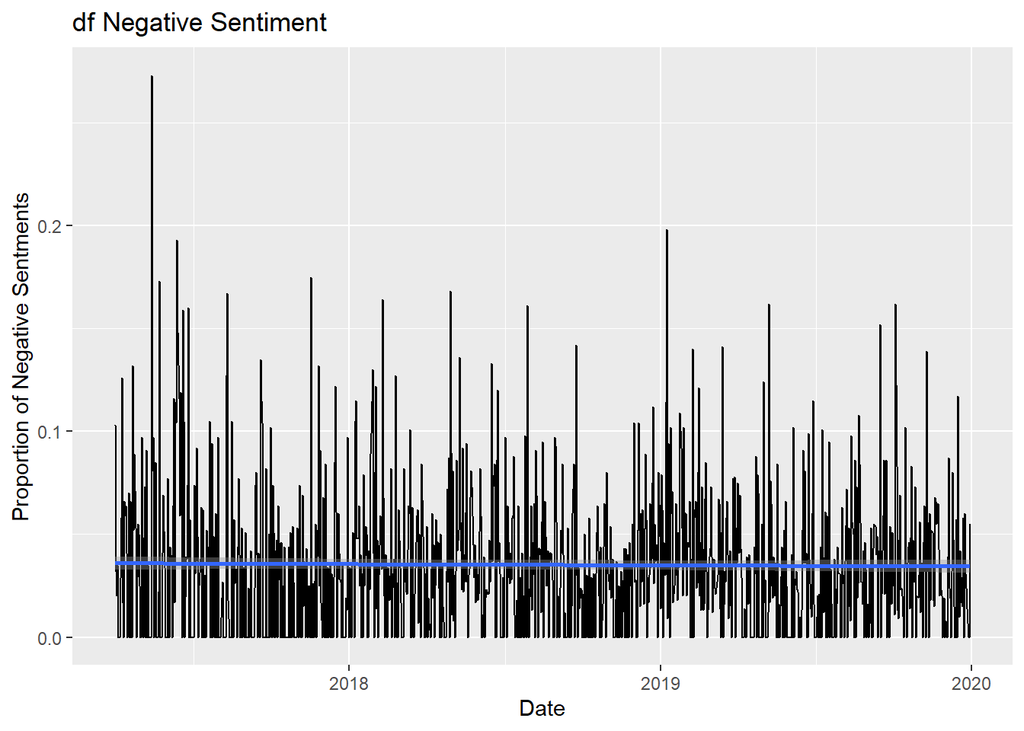

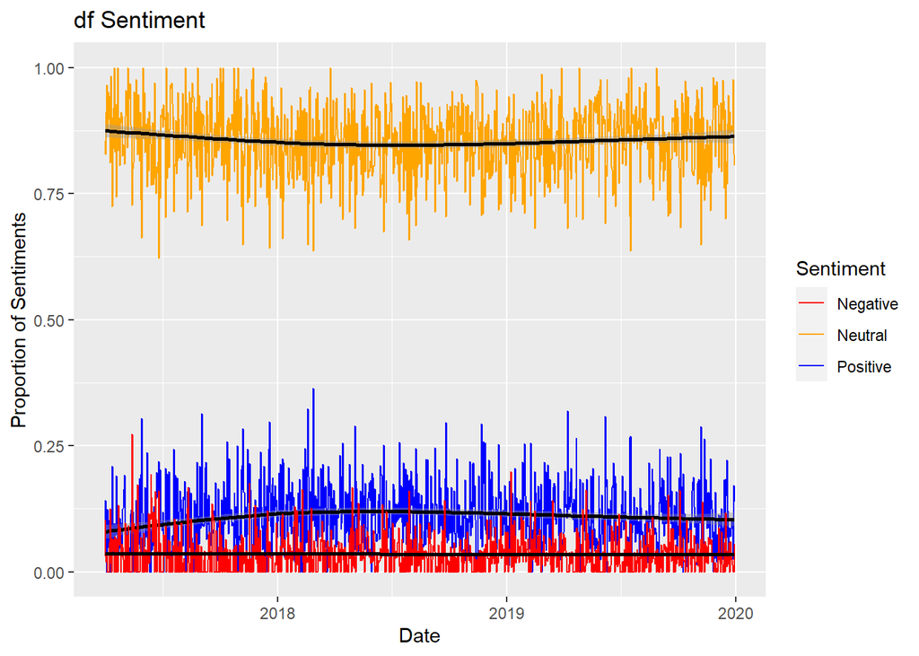

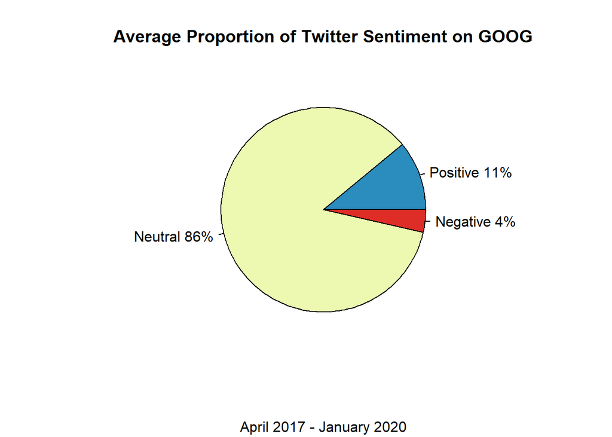

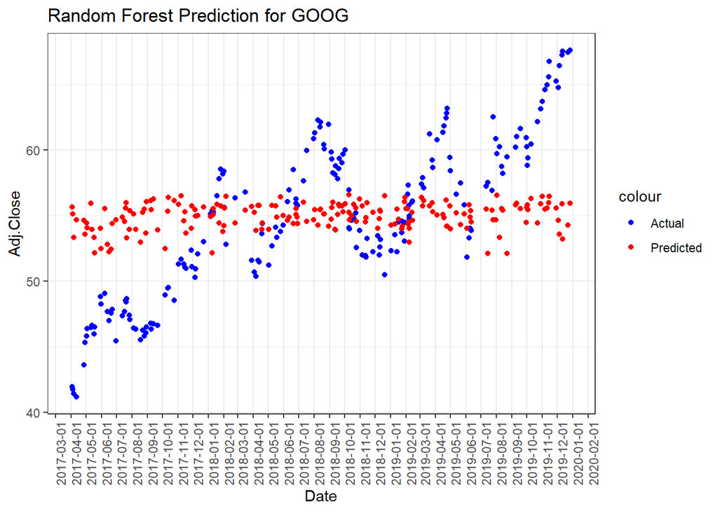

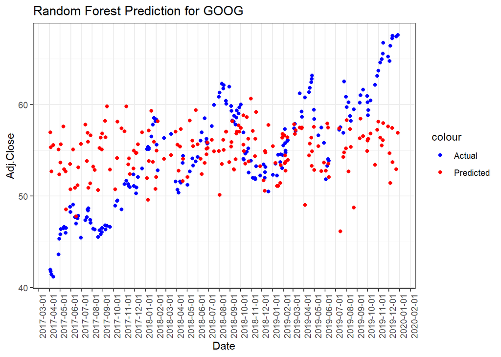

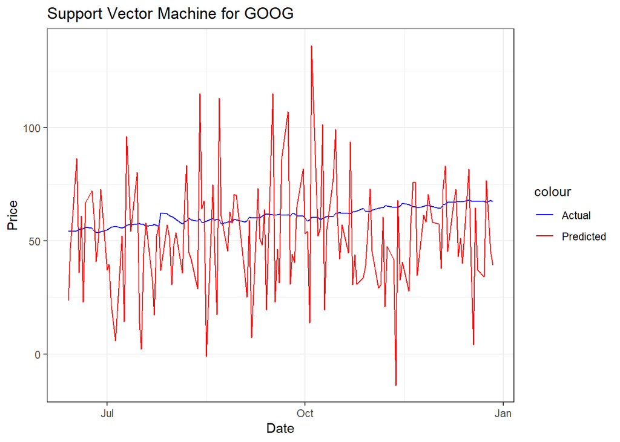

```
## $rmse_test_forest_ranger
## [1] 6.022543
##
## $rmse_test_cv_forest_ranger
## [1] 5.71428
##
## $rmse_svm
## [1] 27.06885
##
## $rmse_neural_network
## [1] 5.501641
```

```r
main('GOOG')
```

### Tesla

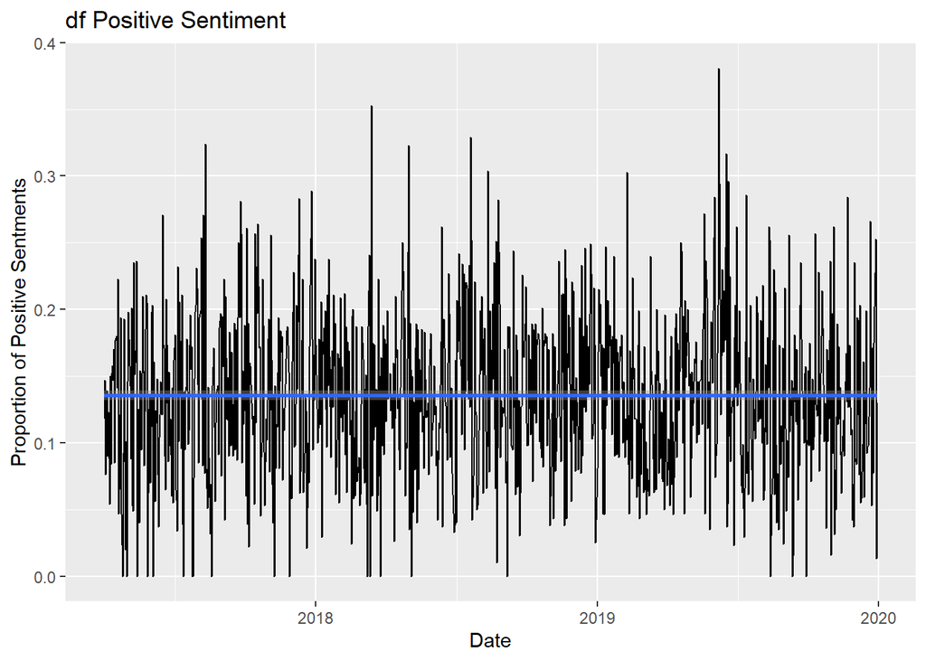

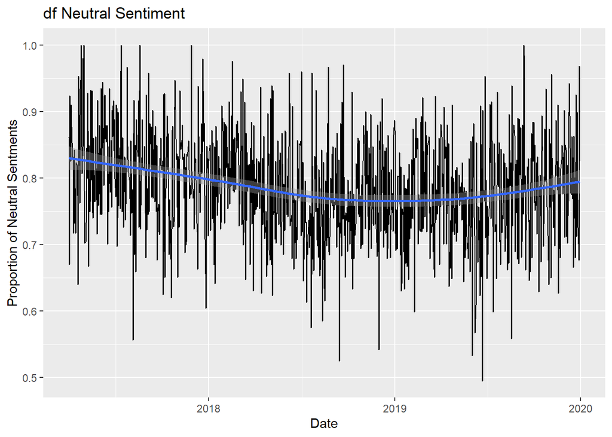

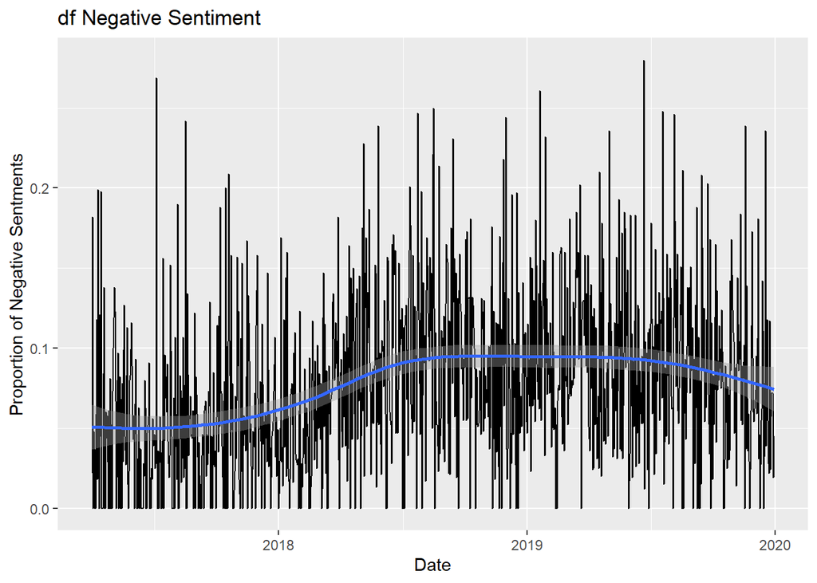

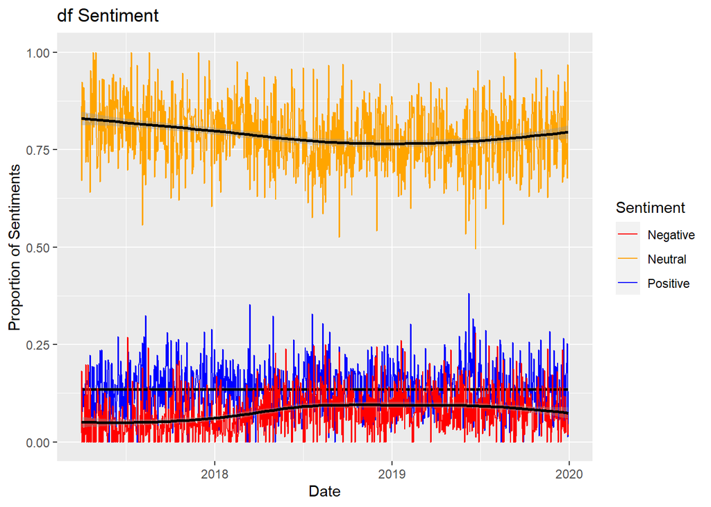

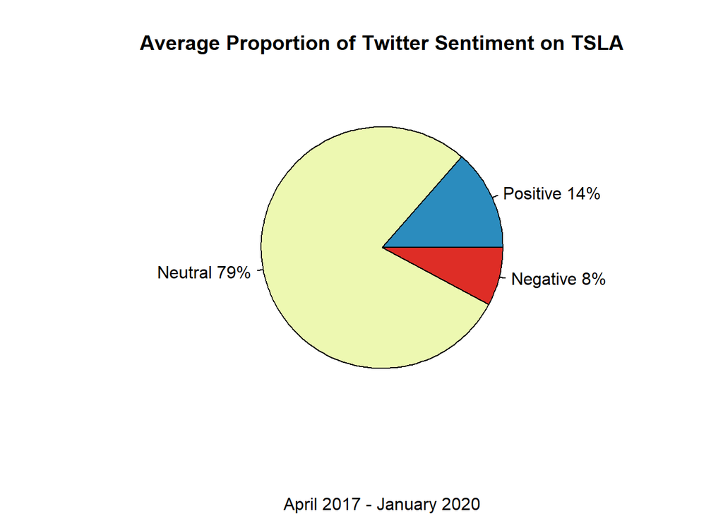

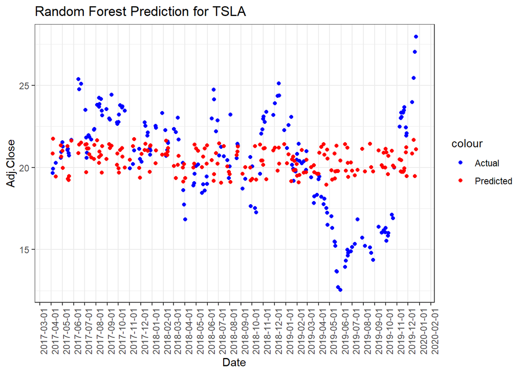

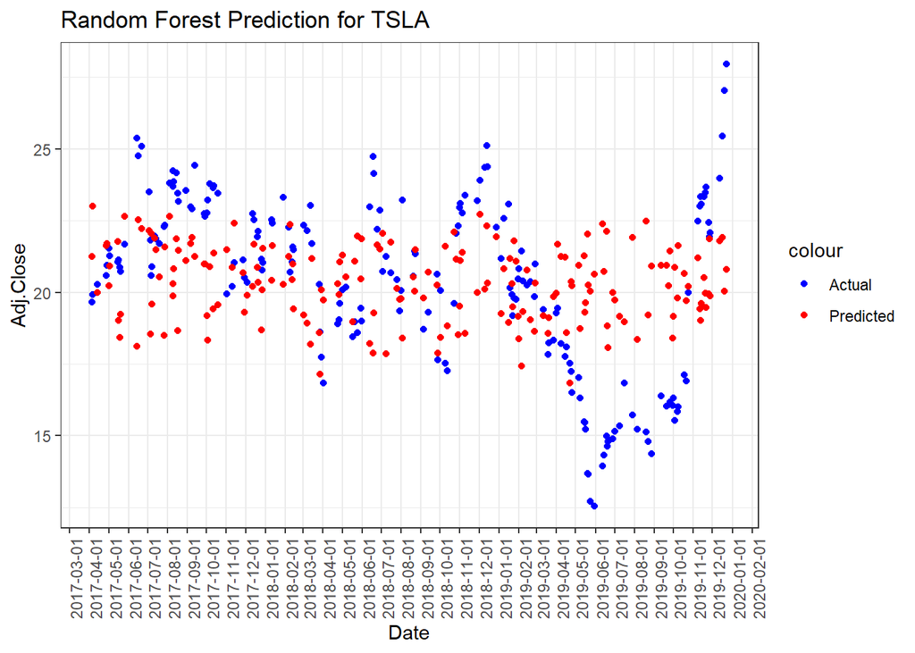

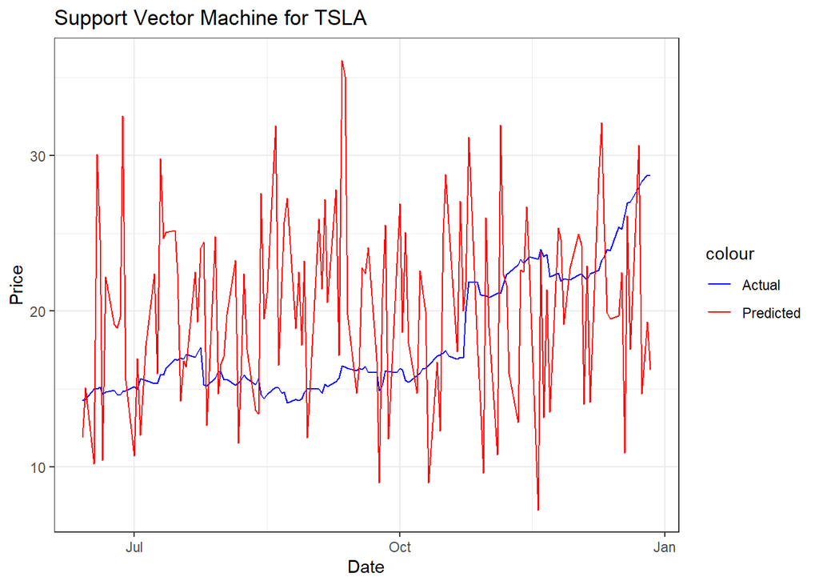

```
## $rmse_test_forest_ranger
## [1] 3.205662
##
## $rmse_test_cv_forest_ranger
## [1] 3.008078
##
## $rmse_svm
## [1] 7.332471
##
## $rmse_neural_network
## [1] 3.016923
```

```r
main('TSLA')
```

### Amazon

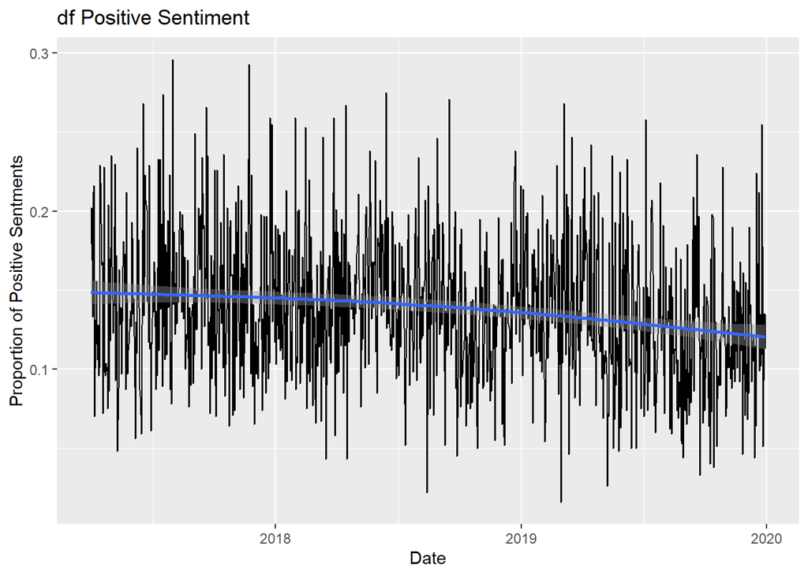

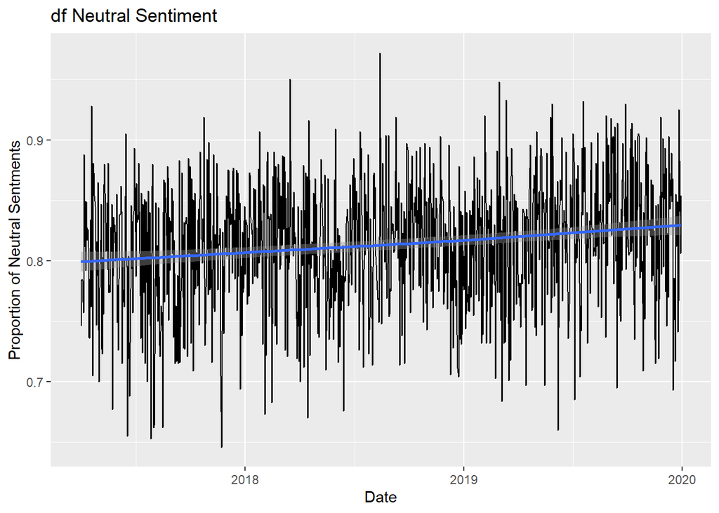

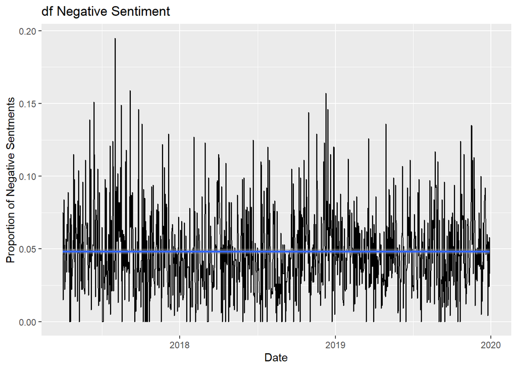

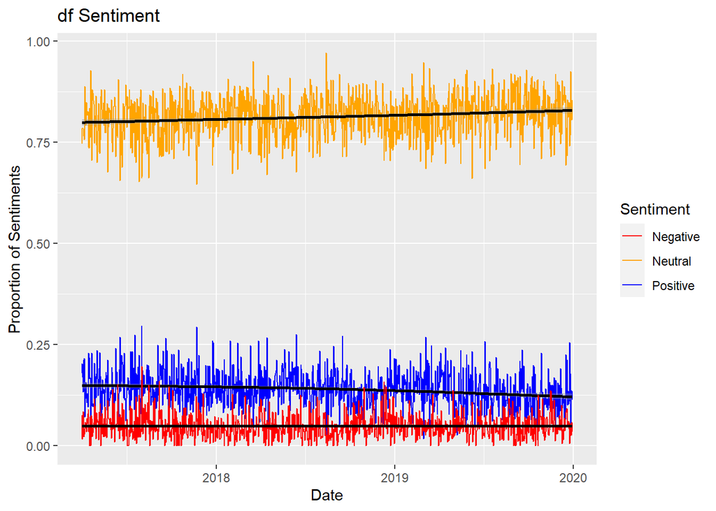

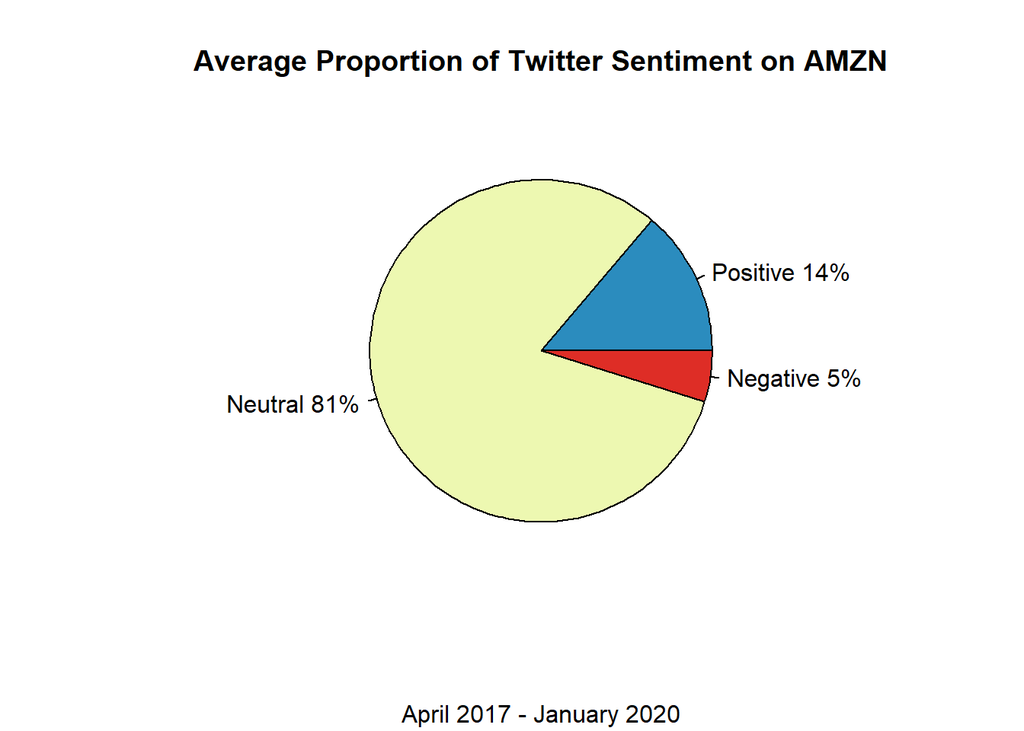

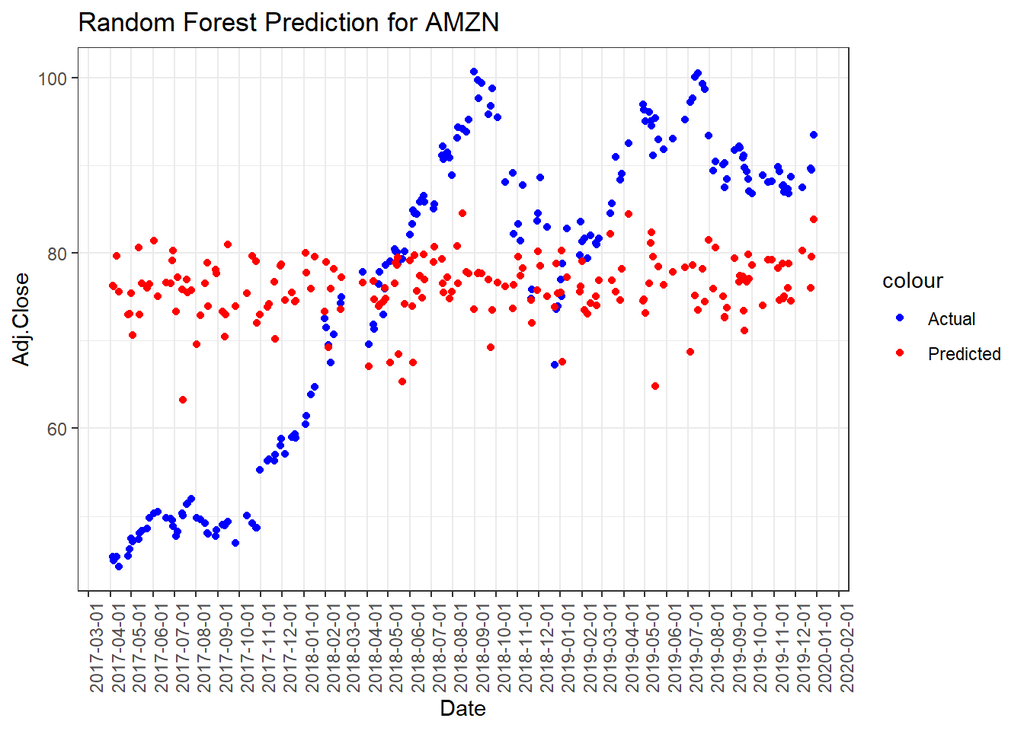

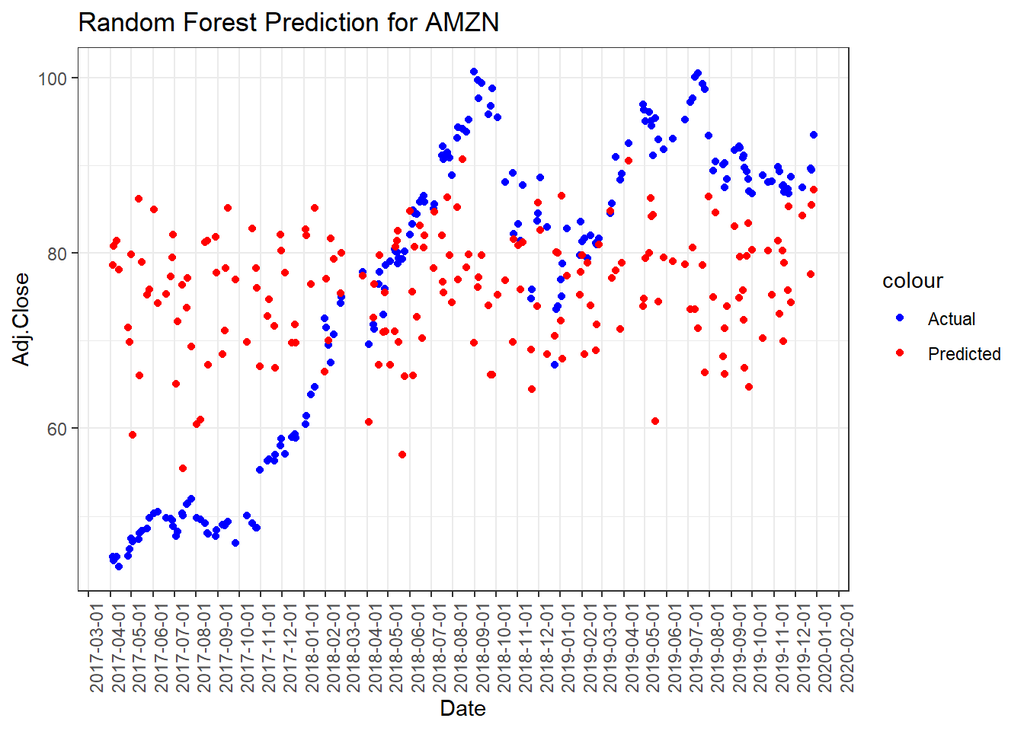

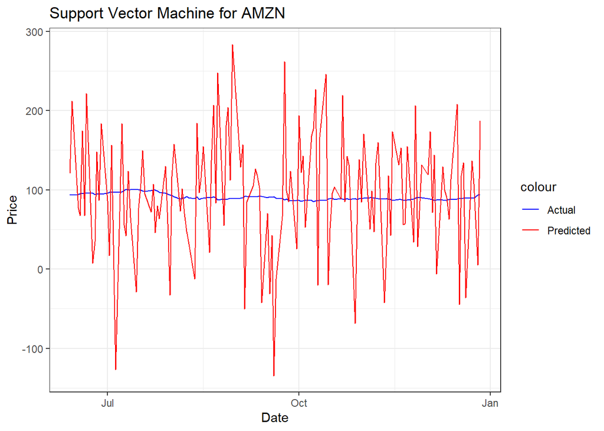

```
## $rmse_test_forest_ranger
## [1] 17.80423
##
## $rmse_test_cv_forest_ranger
## [1] 17.39054
##
## $rmse_svm
## [1] 76.97972
##
## $rmse_neural_network
## [1] 16.62926
```

```r
main('AMZN')
```

### Microsoft

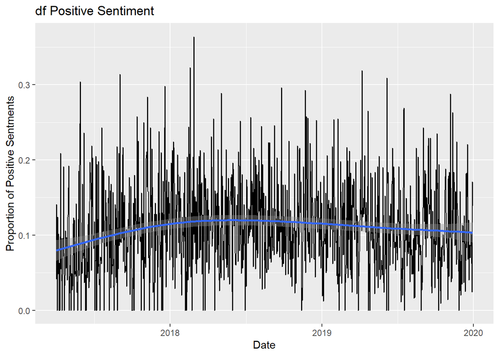

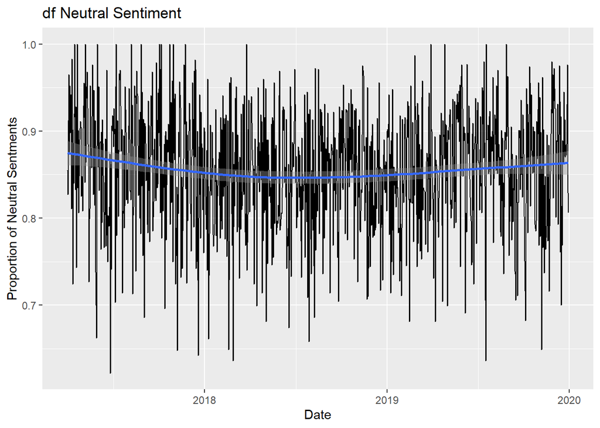

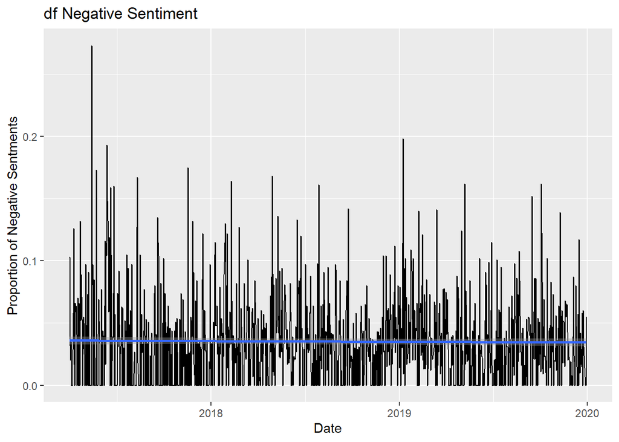

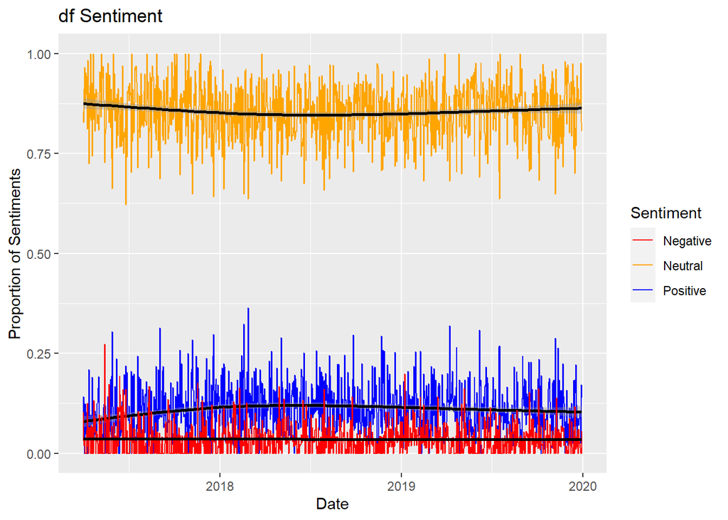

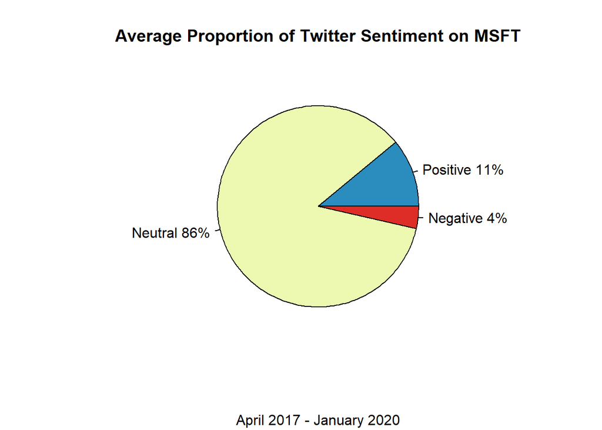

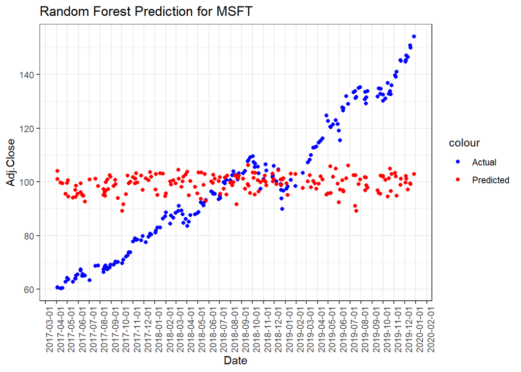

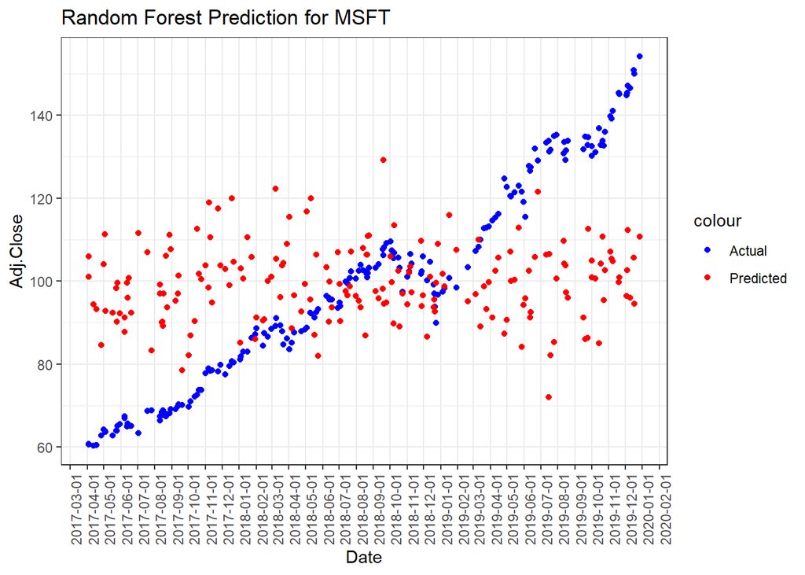

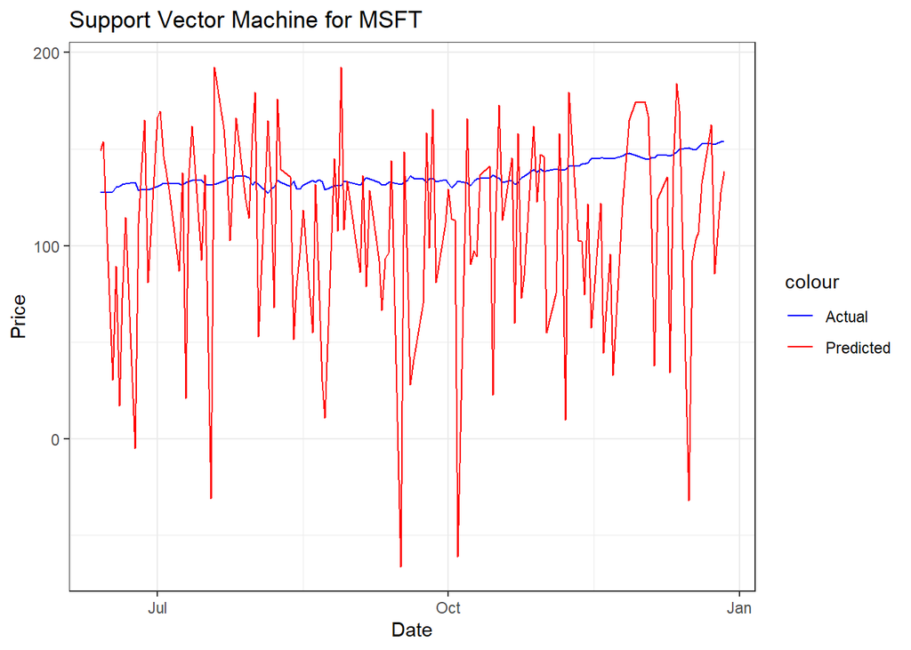

```
## $rmse_test_forest_ranger
## [1] 25.89311
##
## $rmse_test_cv_forest_ranger
## [1] 24.549
##
## $rmse_svm
## [1] 59.65681
##
## $rmse_neural_network
## [1] 23.34197
```

```r
main('MSFT')
```